# Reminder: Vectorized calculations and comparisons

At the core of R is the idea of doing calculations on entire vectors.

```r
gdpTotal <- gap$gdpPercap * gap$pop

gdpSubset <- gap2007$gdpPercap[1:10]

gdpSubset >= 30000
```

```
##  [1] FALSE FALSE FALSE FALSE FALSE  TRUE  TRUE FALSE FALSE  TRUE
```

```r
vec1 <- rnorm(5)
vec2 <- rnorm(5)
vec1 > vec2
```

```
## [1]  TRUE  TRUE  TRUE FALSE  TRUE
```

```r
vec1 == vec2
```

```
## [1] FALSE FALSE FALSE FALSE FALSE
```

```r
vec1 != vec2
```

```
## [1] TRUE TRUE TRUE TRUE TRUE
```

```r
## careful:
vec1 = vec2
identical(vec1, vec2)
```

```
## [1] TRUE
```

```r
## using 'or'
gdpSubset >= 100000 | gdpSubset <= 1000
```

```
##  [1]  TRUE FALSE FALSE FALSE FALSE FALSE FALSE FALSE FALSE FALSE
```

```r
## using 'and'
gap$gdpPercap[1:10] >= 100000 & gap$continent[1:10] == "Asia"
```

```
##  [1] FALSE FALSE FALSE FALSE FALSE FALSE FALSE FALSE FALSE FALSE
```

**POLL 4A**: 2<sup>3</sup> is raising 2 to the power 3, so you get 8.

What will this return?

`(1:4)^(1:4)`

1) an error 2) 1, 2, 3, 4 3) 1, 4, 27, 256 4) 1, 4, 9, 16 5) 1, 16, 81, 256

An important related concept is that of recycling

```r
vec10 <- sample(1:10, 10, replace = TRUE)
vec3 <- sample(1:10, 3, replace = TRUE)
vec5 <- sample(1:10, 5, replace = TRUE)
vec10
```

```
##  [1]  9  1  4  3  6 10 10  6  4  4
```

```r
vec3
```

```
## [1] 10  9  7
```

```r
vec5
```

```
## [1] 6 9 8 9 7
```

```r
vec10 + vec5
```

```
##  [1] 15 10 12 12 13 16 19 14 13 11
```

```r
vec10 + vec3
```

```
##  [1] 19 10 11 13 15 17 20 15 11 14
```

**Question**: Tell me what's going on. What choices were made by the R developers?

**POLL 4B**: What will this return?

```
vec1 <- c(1,2,3,4)
vec2 <- c(1,2)
vec1 + vec2
```

1) 2, 4 2) 2, 4, 5, 6 3) 2, 4, 4, 6 4) an error

# Vectorized calculations

As we've seen, R has many functions that allow you to operate on each element of a vector all at once.

```r
vals <- rnorm(1000)
chi2vals <- vals^2
chi2_df1000 <- sum(chi2vals)
# imagine if the code above were a loop, or three separate loops
```

Advantages:

- much faster than looping
- easier to code
- easier to read and understand the code

Sometimes there are surprises in terms of what is fast, as well as tricks for vectorizing things in unexpected ways:

```r
vals <- rnorm(1e6)
system.time(trunc <- ifelse(vals > 0, vals, 0))
```

```
##    user  system elapsed
##   0.046   0.009   0.055
```

```r
system.time(vals <- vals * (vals > 0))
```

```
##    user  system elapsed
##   0.005   0.000   0.005
```

**Question**: What am I doing with `vals * (vals > 0)` ? What happens behind the scenes in R?

If you use a trick like this, having a comment in your code is a good idea.

Lots of functions in R are vectorized, such as some we've already used.

```r
tmp <- as.character(gap$year)
gap$year2 <- substring(tmp, 3, 4)
head(gap$year2)
```

```
## [1] "52" "57" "62" "67" "72" "77"
```

Question: Note the code above runs and the syntax is perfectly good R syntax, but in terms of what it does, there is a bug in it. See if you can see what it is.

# Linear algebra

R can do essentially any linear algebra you need. It uses system-level packages called BLAS (basic linear algebra subroutines) and LAPACK (linear algebra package). Note that these calculations will be essentially as fast as if you wrote C code because R just calls C and Fortran routines to do the calculations.

The BLAS that comes with R is fairly slow. It's possible to use a faster BLAS, as well as one that uses multiple cores automatically. This can in some cases give you an order of magnitude speedup if your work involves a lot of matrix manipulations/linear algebra. More details in Module 10.

# Vectorized vector/matrix calculations

Recall that `+`, `-`,`*`, `/` do vectorized calculations:

```r
A <- matrix(1:9, 3)
B <- matrix(seq(4,36, by = 4), 3)

A + B
```

```
##      [,1] [,2] [,3]
## [1,]    5   20   35
## [2,]   10   25   40
## [3,]   15   30   45
```

```r
A + B[ , 1]
```

```
##      [,1] [,2] [,3]
## [1,]    5    8   11
## [2,]   10   13   16
## [3,]   15   18   21
```

```r
A * B
```

```
##      [,1] [,2] [,3]
## [1,]    4   64  196
## [2,]   16  100  256
## [3,]   36  144  324
```

```r
A * B[ , 1]
```

```
##      [,1] [,2] [,3]
## [1,]    4   16   28
## [2,]   16   40   64
## [3,]   36   72  108
```

Matrix/vector multiplication

```r
A %*% B[ , 1]
```

```
##      [,1]
## [1,]  120
## [2,]  144
## [3,]  168
```

```r
A %*% B
```

```
##      [,1] [,2] [,3]
## [1,]  120  264  408
## [2,]  144  324  504
## [3,]  168  384  600
```

```r
identical(t(A)%*%A, crossprod(A))
```

```
## [1] TRUE
```

Some decompositions

```r
## next 3 lines generate a positive definite matrix
library(fields)
times <- seq(0, 1, length = 100)
R <- exp(-rdist(times) / 0.2) # a correlation matrix
######################################################
e <- eigen(R)
range(e$values)
```

```
## [1]  0.02525338 32.85537225
```

```r
e$vectors[ , 1]
```

```
##   [1] 0.05195413 0.05448567 0.05698864 0.05946173 0.06190363 0.06431308
##   [7] 0.06668879 0.06902954 0.07133409 0.07360123 0.07582978 0.07801856
##  [13] 0.08016643 0.08227226 0.08433494 0.08635341 0.08832659 0.09025345
##  [19] 0.09213298 0.09396420 0.09574615 0.09747789 0.09915851 0.10078713
##  [25] 0.10236291 0.10388500 0.10535262 0.10676499 0.10812137 0.10942106
##  [31] 0.11066337 0.11184765 0.11297327 0.11403965 0.11504623 0.11599249
##  [37] 0.11687791 0.11770205 0.11846447 0.11916476 0.11980256 0.12037754
##  [43] 0.12088940 0.12133786 0.12172270 0.12204370 0.12230071 0.12249358
##  [49] 0.12262222 0.12268655 0.12268655 0.12262222 0.12249358 0.12230071
##  [55] 0.12204370 0.12172270 0.12133786 0.12088940 0.12037754 0.11980256
##  [61] 0.11916476 0.11846447 0.11770205 0.11687791 0.11599249 0.11504623
##  [67] 0.11403965 0.11297327 0.11184765 0.11066337 0.10942106 0.10812137
##  [73] 0.10676499 0.10535262 0.10388500 0.10236291 0.10078713 0.09915851
##  [79] 0.09747789 0.09574615 0.09396420 0.09213298 0.09025345 0.08832659
##  [85] 0.08635341 0.08433494 0.08227226 0.08016643 0.07801856 0.07582978
##  [91] 0.07360123 0.07133409 0.06902954 0.06668879 0.06431308 0.06190363
##  [97] 0.05946173 0.05698864 0.05448567 0.05195413
```

```r
sv <- svd(R)
U <- chol(R)

devs <- rnorm(100)
Rinvb <- solve(R, devs)  # R^{-1} b
Rinv <- solve(R) # R^{-1} -- try to avoid this
```

# Pre-allocation

This is slow.

```r
vals <- 0
n <- 50000
system.time({
for(i in 1:n)
      vals <- c(vals, i)
})
```

```
##    user  system elapsed
##   2.687   0.003   2.690
```

The same holds for using `rbind()`, `cbind()`, or adding to a list, one element at a time.

Note that we'll discuss for loops in Module 5, but many of you are probably familiar with syntax like this either in R or in other languages.

**Question**: Thoughts on why this are so slow? Think about what R might be doing behind the scenes

# The answer is to pre-allocate memory

This is not so slow. (Please ignore the for-loop hypocrisy and the fact that I could do this as `vals <- 1:n`.)

```r
n <- 50000
system.time({
vals <- rep(0, n)
# alternatively: vals <- as.numeric(NA); length(vals) <- n
for(i in 1:n)
      vals[i] <- i
})
```

```
##    user  system elapsed
##   0.032   0.000   0.033
```

Here's how to pre-allocate an empty list:

```r
vals <- list(); length(vals) <- n
head(vals)
```

# Subsetting

There are many ways to select subsets in R. The syntax below is useful for vectors, matrices, data frames, arrays and lists.

```r
vec <- gap2007$lifeExp
mat <- matrix(1:20, 4, 5)
rownames(mat) <- letters[1:4]
mat
```

```
##   [,1] [,2] [,3] [,4] [,5]
## a    1    5    9   13   17
## b    2    6   10   14   18
## c    3    7   11   15   19
## d    4    8   12   16   20
```

1) by direct indexing

```r
vec[c(3, 5, 12:14)]
```

```
## [1] 72.301 75.320 65.554 74.852 50.728
```

```r
vec[-c(3,5)]
```

```
##   [1] 43.828 76.423 42.731 81.235 79.829 75.635 64.062 79.441 56.728 65.554
##  [11] 74.852 50.728 72.390 73.005 52.295 49.580 59.723 50.430 80.653 44.741
##  [21] 50.651 78.553 72.961 72.889 65.152 46.462 55.322 78.782 48.328 75.748
##  [31] 78.273 76.486 78.332 54.791 72.235 74.994 71.338 71.878 51.579 58.040
##  [41] 52.947 79.313 80.657 56.735 59.448 79.406 60.022 79.483 70.259 56.007
##  [51] 46.388 60.916 70.198 82.208 73.338 81.757 64.698 70.650 70.964 59.545
##  [61] 78.885 80.745 80.546 72.567 82.603 72.535 54.110 67.297 78.623 77.588
##  [71] 71.993 42.592 45.678 73.952 59.443 48.303 74.241 54.467 64.164 72.801
##  [81] 76.195 66.803 74.543 71.164 42.082 62.069 52.906 63.785 79.762 80.204
##  [91] 72.899 56.867 46.859 80.196 75.640 65.483 75.537 71.752 71.421 71.688
## [101] 75.563 78.098 78.746 76.442 72.476 46.242 65.528 72.777 63.062 74.002
## [111] 42.568 79.972 74.663 77.926 48.159 49.339 80.941 72.396 58.556 39.613
## [121] 80.884 81.701 74.143 78.400 52.517 70.616 58.420 69.819 73.923 71.777
## [131] 51.542 79.425 78.242 76.384 73.747 74.249 73.422 62.698 42.384 43.487
```

```r
gap[c(2,4), 5]
```

```
## [1] 30.332 34.020
```

```r
gap[c(2,4), 'lifeExp']
```

```
## [1] 30.332 34.020
```

```r
## more advanced: select using a matrix of indexes
rowInd <- c(1, 3, 4)
colInd <- c(2, 2, 1)
elemInd <- cbind(rowInd, colInd)
elemInd
```

```
##      rowInd colInd
## [1,]      1      2
## [2,]      3      2
## [3,]      4      1
```

```r
gap[elemInd]
```

```
## [1] "1952"        "1962"        "Afghanistan"
```

Note the last usage where we give it a 2-column matrix of indices

2) by a vector of logicals

```r
wealthy <- gap$gdpPercap > 50000
gap$gdpPercap[wealthy]
```

```
## [1] 108382.35 113523.13  95458.11  80894.88 109347.87  59265.48
```

```r
gap[wealthy, ]
```

```
##     country year     pop continent lifeExp gdpPercap year2
## 853  Kuwait 1952  160000      Asia  55.565 108382.35    52
## 854  Kuwait 1957  212846      Asia  58.033 113523.13    57
## 855  Kuwait 1962  358266      Asia  60.470  95458.11    62
## 856  Kuwait 1967  575003      Asia  64.624  80894.88    67
## 857  Kuwait 1972  841934      Asia  67.712 109347.87    72
## 858  Kuwait 1977 1140357      Asia  69.343  59265.48    77
```

What happened in the last subsetting operation?

3) by a vector of names

```r
mat[c('a', 'd', 'a'), ]
```

```
##   [,1] [,2] [,3] [,4] [,5]
## a    1    5    9   13   17
## d    4    8   12   16   20
## a    1    5    9   13   17
```

4) using *subset()*

```r
subset(gap, gdpPercap > 50000)
```

```
##     country year     pop continent lifeExp gdpPercap year2
## 853  Kuwait 1952  160000      Asia  55.565 108382.35    52
## 854  Kuwait 1957  212846      Asia  58.033 113523.13    57
## 855  Kuwait 1962  358266      Asia  60.470  95458.11    62
## 856  Kuwait 1967  575003      Asia  64.624  80894.88    67
## 857  Kuwait 1972  841934      Asia  67.712 109347.87    72
## 858  Kuwait 1977 1140357      Asia  69.343  59265.48    77
```

5) using *dplyr* tools such as *filter()* and *select()* – more in Module 6

# Assignment into subsets

We can assign into subsets by using similar syntax, as we saw with vectors.

```r
vec <- rnorm(20)
vec[c(3, 5, 12:14)] <- 1:5
vec
```

```
##  [1] -0.49232287  0.84233306  1.00000000  1.44386495  2.00000000
##  [6]  0.07375581 -0.37777854  0.64557730 -1.42708799 -0.72326677
## [11] -3.37152569  3.00000000  4.00000000  5.00000000  0.07245229
## [16] -0.30946799 -1.82470834  0.14440634  0.14560218 -0.30229157
```

```r
## Here's a complicated bit of assignment syntax:
mat[2, 3:5] <- rnorm(3)
mat[mat[,1] > 0, ] <- -Inf
mat
```

```
##   [,1] [,2] [,3] [,4] [,5]
## a -Inf -Inf -Inf -Inf -Inf
## b -Inf -Inf -Inf -Inf -Inf
## c -Inf -Inf -Inf -Inf -Inf
## d -Inf -Inf -Inf -Inf -Inf
```

# Factors

- A factor is a special data type in R used for categorical data. In some cases it works like magic and in others it is incredibly frustrating.

```r
## let's read the Gapminder data in using the defaults for `read.csv`
gap <- read.csv(file.path('..', 'data', 'gapminder-FiveYearData.csv'), stringsAsFactors = TRUE)
class(gap$continent)
```

```
## [1] "factor"
```

```r
head(gap$continent) # What order are the factors in?
```

```
## [1] Asia Asia Asia Asia Asia Asia
## Levels: Africa Americas Asia Europe Oceania
```

```r
levels(gap[["continent"]])  # note alternate way to get the variable
```

```
## [1] "Africa"   "Americas" "Asia"     "Europe"   "Oceania"
```

```r
summary(gap$continent)
```

```
##   Africa Americas     Asia   Europe  Oceania
##      624      300      396      360       24
```

- What if we don't like the order these are in? Factor order is important for all kinds of things like plotting, analysis of variance, regression output, and more

# Ordering the Factor

- Ordered factors simply have an additional attribute explaining the order of the levels of a factor
- This is a useful shortcut when we want to preserve some of the meaning provided by the order
- Think ordinal data

This example is a bit artificial as 'continent' doesn't really have a natural ordering.

```r
gap$continent2 <- ordered(gap$continent,
     levels = levels(gap$continent)[c(2,1,3,4,5)])

head(gap$continent2)
```

```
## [1] Asia Asia Asia Asia Asia Asia
## Levels: Americas < Africa < Asia < Europe < Oceania
```

```r
levels(gap$continent2)
```

```
## [1] "Americas" "Africa"   "Asia"     "Europe"   "Oceania"
```

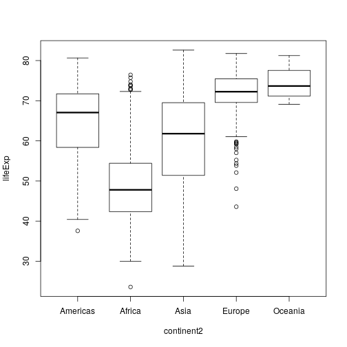

```r
boxplot(lifeExp ~ continent2, data = gap)
```

# (Advanced) Reclassifying Factors

- Turning factors into other data types can be tricky. All factors have an underlying numeric structure.

```r
students <- factor(c('basic','proficient','advanced','basic',
      'advanced', 'minimal'))
levels(students)
```

```
## [1] "advanced"   "basic"      "minimal"    "proficient"
```

```r
unclass(students)
```

```
## [1] 2 4 1 2 1 3
## attr(,"levels")
## [1] "advanced"   "basic"      "minimal"    "proficient"
```

- Hmmm, what happened?
- Be careful! The best way to convert a factor is to convert it to a character first.

```r
students <- factor(c('basic','proficient','advanced','basic',
      'advanced', 'minimal'))
score = c(minimal = 3, basic = 1, advanced = 13, proficient = 7) # a named vector
score["advanced"]  # look up by name
```

```
## advanced
##       13
```

```r
students[3]
```

```
## [1] advanced
## Levels: advanced basic minimal proficient
```

```r
score[students[3]]
```

```
## minimal
##       3
```

```r
score[as.character(students[3])]
```

```
## advanced
##       13
```

What went wrong and how did we fix it? Notice how easily this could be a big bug in your code.

# Tabulation

- Sometimes we need to do some basic checking for the number of observations or types of observations in our dataset
- To do this quickly and easily, `table()` is our friend

```r
tbl <- table(gap$country, gap$continent)
tbl
```

```
##
##                            Africa Americas Asia Europe Oceania
##   Afghanistan                   0        0   12      0       0
##   Albania                       0        0    0     12       0
##   Algeria                      12        0    0      0       0
##   Angola                       12        0    0      0       0
##   Argentina                     0       12    0      0       0
##   Australia                     0        0    0      0      12
##   Austria                       0        0    0     12       0
##   Bahrain                       0        0   12      0       0
##   Bangladesh                    0        0   12      0       0
##   Belgium                       0        0    0     12       0
##   Benin                        12        0    0      0       0
##   Bolivia                       0       12    0      0       0
##   Bosnia and Herzegovina        0        0    0     12       0
##   Botswana                     12        0    0      0       0
##   Brazil                        0       12    0      0       0
##   Bulgaria                      0        0    0     12       0
##   Burkina Faso                 12        0    0      0       0
##   Burundi                      12        0    0      0       0
##   Cambodia                      0        0   12      0       0
##   Cameroon                     12        0    0      0       0
##   Canada                        0       12    0      0       0
##   Central African Republic     12        0    0      0       0
##   Chad                         12        0    0      0       0
##   Chile                         0       12    0      0       0
##   China                         0        0   12      0       0
##   Colombia                      0       12    0      0       0
##   Comoros                      12        0    0      0       0
##   Congo Dem. Rep.              12        0    0      0       0
##   Congo Rep.                   12        0    0      0       0
##   Costa Rica                    0       12    0      0       0
##   Cote d'Ivoire                12        0    0      0       0
##   Croatia                       0        0    0     12       0
##   Cuba                          0       12    0      0       0
##   Czech Republic                0        0    0     12       0
##   Denmark                       0        0    0     12       0
##   Djibouti                     12        0    0      0       0
##   Dominican Republic            0       12    0      0       0
##   Ecuador                       0       12    0      0       0
```

[output cut: 89 more lines]

```
##   Thailand                      0        0   12      0       0
##   Togo                         12        0    0      0       0
##   Trinidad and Tobago           0       12    0      0       0
##   Tunisia                      12        0    0      0       0
##   Turkey                        0        0    0     12       0
##   Uganda                       12        0    0      0       0
##   United Kingdom                0        0    0     12       0
##   United States                 0       12    0      0       0
##   Uruguay                       0       12    0      0       0
##   Venezuela                     0       12    0      0       0
##   Vietnam                       0        0   12      0       0
##   West Bank and Gaza            0        0   12      0       0
##   Yemen Rep.                    0        0   12      0       0
##   Zambia                       12        0    0      0       0
##   Zimbabwe                     12        0    0      0       0
```

```r
range(tbl)
```

```
## [1]  0 12
```

```r
table(tbl)
```

```
## tbl
##   0  12
## 568 142
```

# Discretization

You may need to discretize a continuous variable (or a discrete variable with many levels), e.g., by life expectancy:

```r
gap2007$lifeExpBin <- cut(gap2007$lifeExp, breaks = c(0, 40, 50, 60, 70, 75, 80, Inf))
tbl <- table(gap2007$continent, gap2007$lifeExpBin)
round( prop.table(tbl, margin = 1), 2 )
```

```
##
##            (0,40] (40,50] (50,60] (60,70] (70,75] (75,80] (80,Inf]
##   Africa     0.02    0.33    0.42    0.10    0.12    0.02     0.00
##   Americas   0.00    0.00    0.00    0.12    0.48    0.36     0.04
##   Asia       0.00    0.03    0.06    0.24    0.39    0.18     0.09
##   Europe     0.00    0.00    0.00    0.00    0.27    0.50     0.23
##   Oceania    0.00    0.00    0.00    0.00    0.00    0.00     1.00
```

# Stratified analyses I

Often we want to do individual analyses within subsets or clusters of our data.

As a first step, we might want to just split our dataset by a stratifying variable.

```r
subsets <- split(gap,  gap$year)
length(subsets)
```

```
## [1] 12
```

```r
dim(subsets[['2007']])
```

```
## [1] 142   7
```

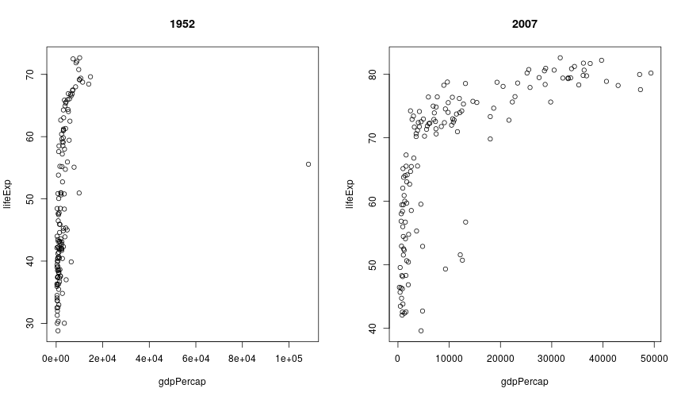

```r
par(mfrow = c(1,2))
plot(lifeExp ~ gdpPercap, data = subsets[['1952']], main = '1952')
abline(h = 0, col = 'grey')
plot(lifeExp ~ gdpPercap, data = subsets[['2007']], main = '2007')
abline(h = 0, col = 'grey')
```

Obviously, we'd want to iterate to improve that plot given the outlier.

**POLL 4C**: What kind of object is produced by

```
split, e.g., subsets <- split(gap,  gap$year)
```

1) a dataframe 2) a list 3) a list of lists 4) a list of dataframes 5) some new kind of object we haven't encountered yet

# Stratified analyses II

Often we want to do individual analyses within subsets or clusters of our data. R has a variety of tools for this; for now we'll look at `aggregate()` and `by()`. These are wrappers of `tapply()`.

```r
gmSmall <- gap[ , c('lifeExp', 'gdpPercap')]  # reduce to only numeric columns
aggregate(gmSmall, by = list(year = gap$year), FUN = median, na.rm = TRUE) # na.rm not needed here but illustrates use of additional arguments to FUN
```

```
##    year lifeExp gdpPercap
## 1  1952 45.1355  1968.528
## 2  1957 48.3605  2173.220
## 3  1962 50.8810  2335.440
## 4  1967 53.8250  2678.335
## 5  1972 56.5300  3339.129
## 6  1977 59.6720  3798.609
## 7  1982 62.4415  4216.228
## 8  1987 65.8340  4280.300
## 9  1992 67.7030  4386.086
## 10 1997 69.3940  4781.825
## 11 2002 70.8255  5319.805
## 12 2007 71.9355  6124.371
```

```r
aggregate(lifeExp ~ year + continent, data = gap, FUN = median)
```

```
##    year continent lifeExp
## 1  1952    Africa 38.8330
## 2  1957    Africa 40.5925
## 3  1962    Africa 42.6305
## 4  1967    Africa 44.6985
## 5  1972    Africa 47.0315
## 6  1977    Africa 49.2725
## 7  1982    Africa 50.7560
## 8  1987    Africa 51.6395
## 9  1992    Africa 52.4290
## 10 1997    Africa 52.7590
## 11 2002    Africa 51.2355
## 12 2007    Africa 52.9265
## 13 1952  Americas 54.7450
## 14 1957  Americas 56.0740
```

[output cut: 46 more lines]

```r
agg <- aggregate(lifeExp ~ year + continent , data = gap, FUN = median)
xtabs(lifeExp ~ ., data = agg)
```

```
##       continent
## year    Africa Americas    Asia  Europe Oceania
##   1952 38.8330  54.7450 44.8690 65.9000 69.2550
##   1957 40.5925  56.0740 48.2840 67.6500 70.2950
##   1962 42.6305  58.2990 49.3250 69.5250 71.0850
##   1967 44.6985  60.5230 53.6550 70.6100 71.3100
##   1972 47.0315  63.4410 56.9500 70.8850 71.9100
##   1977 49.2725  66.3530 60.7650 72.3350 72.8550
##   1982 50.7560  67.4050 63.7390 73.4900 74.2900
##   1987 51.6395  69.4980 66.2950 74.8150 75.3200
##   1992 52.4290  69.8620 68.6900 75.4510 76.9450
##   1997 52.7590  72.1460 70.2650 76.1160 78.1900
##   2002 51.2355  72.0470 71.0280 77.5365 79.7400
##   2007 52.9265  72.8990 72.3960 78.6085 80.7195
```

Notice the 'long' vs. 'wide' formats. You'll see more about that sort of thing in Module 6.

# Stratified analyses III

`aggregate()` works fine when the output is univariate, but what about more complicated analyses than computing the median, such as fitting a set of regressions?

```r
out <- by(gap, gap$year,
    function(sub) {
      lm(lifeExp ~ log(gdpPercap), data = sub)
    }
)
length(out)
```

```
## [1] 12
```

```r
summary(out[['2007']])
```

```
##
## Call:
## lm(formula = lifeExp ~ log(gdpPercap), data = sub)
##
## Residuals:
##     Min      1Q  Median      3Q     Max
## -25.947  -2.661   1.215   4.469  13.115
##
## Coefficients:
##                Estimate Std. Error t value Pr(>|t|)
## (Intercept)      4.9496     3.8577   1.283    0.202
## log(gdpPercap)   7.2028     0.4423  16.283   <2e-16 ***
## ---
## Signif. codes:  0 '***' 0.001 '**' 0.01 '*' 0.05 '.' 0.1 ' ' 1
##
## Residual standard error: 7.122 on 140 degrees of freedom
## Multiple R-squared:  0.6544, Adjusted R-squared:  0.652
## F-statistic: 265.2 on 1 and 140 DF,  p-value: < 2.2e-16
```

```r
summary(out[['1952']])
```

```
##
## Call:
## lm(formula = lifeExp ~ log(gdpPercap), data = sub)
##
## Residuals:
##      Min       1Q   Median       3Q      Max
## -28.9571  -5.7319   0.7517   6.5770  13.7361
##
## Coefficients:
##                Estimate Std. Error t value Pr(>|t|)
## (Intercept)    -17.8457     5.0668  -3.522 0.000578 ***
## log(gdpPercap)   8.8298     0.6626  13.326  < 2e-16 ***
## ---
## Signif. codes:  0 '***' 0.001 '**' 0.01 '*' 0.05 '.' 0.1 ' ' 1
##
## Residual standard error: 8.146 on 140 degrees of freedom
## Multiple R-squared:  0.5592, Adjusted R-squared:  0.556
## F-statistic: 177.6 on 1 and 140 DF,  p-value: < 2.2e-16
```

# Sorting

`sort()` applied to a vector does what you expect.

Sorting a matrix or dataframe based on one or more columns is a somewhat manual process, but once you get the hang of it, it's not bad.

```r
ord <- order(gap$year, gap$lifeExp, decreasing = TRUE)
ord[1:5]
```

```
## [1]  804  672  696 1488   72
```

```r
gm_ord <- gap[ord, ]
head(gm_ord)
```

```
##              country year       pop continent lifeExp gdpPercap continent2
## 804            Japan 2007 127467972      Asia  82.603  31656.07       Asia
## 672  Hong Kong China 2007   6980412      Asia  82.208  39724.98       Asia
## 696          Iceland 2007    301931    Europe  81.757  36180.79     Europe
## 1488     Switzerland 2007   7554661    Europe  81.701  37506.42     Europe
## 72         Australia 2007  20434176   Oceania  81.235  34435.37    Oceania
## 1428           Spain 2007  40448191    Europe  80.941  28821.06     Europe
```

You could of course write your own *sort* function that uses `order()`. More in Module 6.

# Merging Data

We often need to combine data across multiple data frames, merging on common fields (i.e., *keys*). In database terminology, this is a *join* operation.

Suppose that our dataset did not have 'continent' in it, but that we had a separate data frame that matches country to continent.

```r
# ignore the 'wizard' behind the curtain...
c2c <- unique(gap[ , c('country', 'continent')])
gapSave <- gap
gap <- gap[ , -which(names(gap) == "continent")]
```

Now let's add the continent info in:

```r
head(c2c)
```

```
##        country continent
## 1  Afghanistan      Asia
## 13     Albania    Europe
## 25     Algeria    Africa
## 37      Angola    Africa
## 49   Argentina  Americas
## 61   Australia   Oceania
```

```r
head(gap)
```

```
##       country year      pop lifeExp gdpPercap continent2
## 1 Afghanistan 1952  8425333  28.801  779.4453       Asia
## 2 Afghanistan 1957  9240934  30.332  820.8530       Asia
## 3 Afghanistan 1962 10267083  31.997  853.1007       Asia
## 4 Afghanistan 1967 11537966  34.020  836.1971       Asia
## 5 Afghanistan 1972 13079460  36.088  739.9811       Asia
## 6 Afghanistan 1977 14880372  38.438  786.1134       Asia
```

```r
gap <- merge(gap, c2c, by.x = 'country', by.y = 'country',
                   all.x = TRUE, all.y = FALSE)

dim(gapSave)
```

```
## [1] 1704    7
```

```r
dim(gap)
```

```
## [1] 1704    7
```

```r
identical(gapSave, gap)
```

```
## [1] FALSE
```

```r
identical(gapSave, gap[ , names(gapSave)])
```

```
## [1] TRUE
```

What's the deal with the `all.x` and `all.y` ? We can tell R whether we want to keep all of the `x` observations, all the `y` observations, or neither, or both, when there may be rows in either of the datasets that don't match the other dataset.

# Describing relationships

- Once we've carried out group-wise operations and perhaps reshaped it, we may also like to describe the relationships in the data. Often this involves fitting some style of regression model. The goal can be pure prediction, description, or inferring a causal relationship between variables.

Of course to infer causality, one has to be quite careful and techniques that try to avoid the usual pitfall that correlation is not causation are way beyond what we can cover here.

We'll just see the basics of how to fit regressions here.

# Inference/Regression

- Running regressions in R is generally straightforward.
- Most basic, catch-all regression function in R is *glm*
- *glm* fits a generalized linear model with your choice of family/link function (gaussian, logit, poisson, etc.)
- *lm* is just a standard linear regression (equivalent to glm with family = gaussian(link = “identity”))
- The basic glm call looks something like this:

```r
glm(formula = y ~ x1 + x2 + x3 + ..., family = familyname(link = "linkname"),
            data = )
```

- There are a bunch of families and links to use (help(family) for a full list), but some essentials are **binomial(link = “logit”)**, **gaussian(link = “identity”)**, and **poisson(link = “log”)**

If you're using `lm`, the call looks the same but without the `family` argument.

- Example: suppose we want to regress the life expectency on the GDP per capita and the population, as well as the continent and year. The lm/glm call would be something like this:

```r
reg <- lm(formula = lifeExp ~ log(gdpPercap) + log(pop) + continent + year,
                data = gap)
```

**POLL 4D**:

Consider this regression model:

```
reg <- lm(formula = lifeExp ~ log(gdpPercap) + log(pop) + continent + year,
                data = gap)
```

*Question 1*: 'continent' could be:

1) numeric 2) character 3) factor 4) none of the above

*Question 2*: 'year' should be:

1) numeric 2) factor 3) character 4) none of the above

# Regression output

- When we store this regression in an object, we get access to several items of interest

```r
# View components contained in the regression output
names(reg)
```

```
##  [1] "coefficients"  "residuals"     "effects"       "rank"
##  [5] "fitted.values" "assign"        "qr"            "df.residual"
##  [9] "contrasts"     "xlevels"       "call"          "terms"
## [13] "model"
```

```r
# Examine regression coefficients
reg$coefficients
```

```
##       (Intercept)    log(gdpPercap)          log(pop) continentAmericas
##      -460.8132741         5.0756110         0.1530312         8.7453560
##     continentAsia   continentEurope  continentOceania              year
##         6.8254916        12.2808442        12.5398669         0.2377202
```

```r
# Examine regression degrees of freedom
reg$df.residual
```

```
## [1] 1696
```

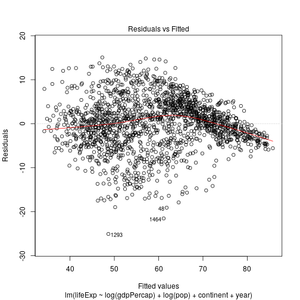

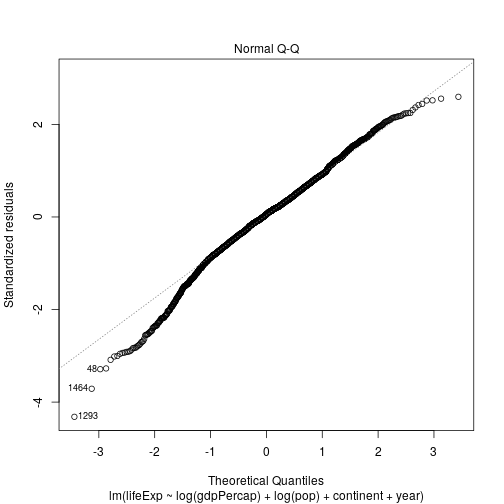

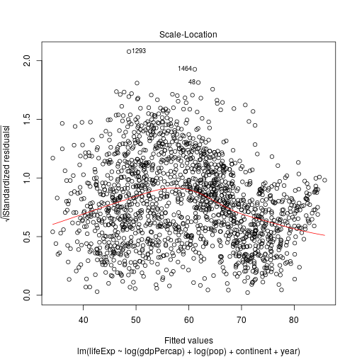

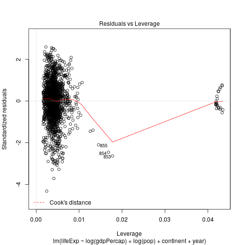

```r
# See the standard (diagnostic) plots for a regression
plot(reg)
```

**POLL 4E** Suppose you see this syntax when using the output of a regression:

```
reg$coefficients
```

The `reg` object is:

1) a list 2) a numeric vector 3) a dataframe 4) something else

- R has a helpful summary method for regression objects

```r
summary(reg)
```

```
##
## Call:
## lm(formula = lifeExp ~ log(gdpPercap) + log(pop) + continent +
##     year, data = gap)
##
## Residuals:
##      Min       1Q   Median       3Q      Max
## -25.0572  -3.2857   0.3289   3.7062  15.0650
##
## Coefficients:
##                     Estimate Std. Error t value Pr(>|t|)
## (Intercept)       -4.608e+02  1.697e+01 -27.154   <2e-16 ***
## log(gdpPercap)     5.076e+00  1.627e-01  31.191   <2e-16 ***
## log(pop)           1.530e-01  9.668e-02   1.583    0.114
## continentAmericas  8.745e+00  4.766e-01  18.349   <2e-16 ***
## continentAsia      6.825e+00  4.232e-01  16.128   <2e-16 ***
## continentEurope    1.228e+01  5.292e-01  23.205   <2e-16 ***
## continentOceania   1.254e+01  1.281e+00   9.788   <2e-16 ***
## year               2.377e-01  8.932e-03  26.614   <2e-16 ***
## ---
## Signif. codes:  0 '***' 0.001 '**' 0.01 '*' 0.05 '.' 0.1 ' ' 1
##
## Residual standard error: 5.811 on 1696 degrees of freedom
## Multiple R-squared:  0.7985, Adjusted R-squared:  0.7976
## F-statistic:   960 on 7 and 1696 DF,  p-value: < 2.2e-16
```

- Can also extract useful things from the summary object

```r
# Store summary method results
summ_reg <- summary(reg)
# View summary method results objects
objects(summ_reg)
```

```
##  [1] "adj.r.squared" "aliased"       "call"          "coefficients"
##  [5] "cov.unscaled"  "df"            "fstatistic"    "r.squared"
##  [9] "residuals"     "sigma"         "terms"
```

```r
# View table of coefficients
summ_reg$coefficients
```

```
##                       Estimate   Std. Error    t value      Pr(>|t|)
## (Intercept)       -460.8132741 16.970277820 -27.154138 3.961833e-135
## log(gdpPercap)       5.0756110  0.162724177  31.191499 3.371693e-169
## log(pop)             0.1530312  0.096677948   1.582897  1.136315e-01
## continentAmericas    8.7453560  0.476599244  18.349496  9.605994e-69
## continentAsia        6.8254916  0.423203644  16.128149  1.492420e-54
## continentEurope     12.2808442  0.529239698  23.204692 1.123344e-103
## continentOceania    12.5398669  1.281141831   9.788040  4.798636e-22
## year                 0.2377202  0.008932106  26.614126 1.058968e-130
```

- Note that, in our results, R has broken up our variables into their different factor levels (as it will do whenever your regressors have factor levels)
- If your data aren't factorized, you can tell lm/glm to factorize a variable (i.e. create dummy variables on the fly) by writing

```r
glm(formula = y ~ x1 + x2 + factor(x3), family = family(link = "link"),
            data = )
```

# Setting up regression interactions

- There are also some useful shortcuts for regressing on interaction terms:

`x1:x2` interacts all terms in x1 with all terms in x2

```r
summary(lm(lifeExp ~ log(gdpPercap) + log(pop) +
                    continent:factor(year),
                    data = gap))
```

```
##
## Call:
## lm(formula = lifeExp ~ log(gdpPercap) + log(pop) + continent:factor(year),
##     data = gap)
##
## Residuals:
##      Min       1Q   Median       3Q      Max
## -26.5678  -2.5530   0.0044   2.9146  15.5667
##
## Coefficients: (1 not defined because of singularities)
##                                     Estimate Std. Error t value Pr(>|t|)
## (Intercept)                         27.18384    4.68490   5.802 7.83e-09
## log(gdpPercap)                       5.07950    0.16049  31.650  < 2e-16
## log(pop)                             0.07894    0.09427   0.837 0.402510
## continentAfrica:factor(year)1952   -24.14252    4.11250  -5.871 5.25e-09
## continentAmericas:factor(year)1952 -16.44650    4.16627  -3.948 8.23e-05
## continentAsia:factor(year)1952     -19.33470    4.14083  -4.669 3.27e-06
## continentEurope:factor(year)1952    -7.09176    4.13518  -1.715 0.086537
## continentOceania:factor(year)1952   -6.06350    5.65111  -1.073 0.283440
## continentAfrica:factor(year)1957   -22.49637    4.10985  -5.474 5.09e-08
## continentAmericas:factor(year)1957 -14.36734    4.16433  -3.450 0.000575
## continentAsia:factor(year)1957     -17.17434    4.13753  -4.151 3.48e-05
## continentEurope:factor(year)1957    -5.90941    4.13272  -1.430 0.152934
## continentOceania:factor(year)1957   -5.62997    5.65034  -0.996 0.319206
## continentAfrica:factor(year)1962   -21.01387    4.10690  -5.117 3.47e-07
## continentAmericas:factor(year)1962 -12.31354    4.16305  -2.958 0.003143
## continentAsia:factor(year)1962     -15.56258    4.13513  -3.764 0.000173
## continentEurope:factor(year)1962    -5.05421    4.13082  -1.224 0.221302
## continentOceania:factor(year)1962   -5.31223    5.64979  -0.940 0.347226
## continentAfrica:factor(year)1967   -19.70336    4.10348  -4.802 1.72e-06
## continentAmericas:factor(year)1967 -10.93238    4.16129  -2.627 0.008690
## continentAsia:factor(year)1967     -13.15690    4.13270  -3.184 0.001482
## continentEurope:factor(year)1967    -4.91343    4.12905  -1.190 0.234232
## continentOceania:factor(year)1967   -5.77117    5.64916  -1.022 0.307122
## continentAfrica:factor(year)1972   -18.14692    4.10075  -4.425 1.03e-05
## continentAmericas:factor(year)1972  -9.65366    4.15954  -2.321 0.020417
## continentAsia:factor(year)1972     -11.60139    4.12929  -2.810 0.005020
## continentEurope:factor(year)1972    -4.97628    4.12753  -1.206 0.228133
## continentOceania:factor(year)1972   -5.80936    5.64868  -1.028 0.303891
## continentAfrica:factor(year)1977   -16.18475    4.09960  -3.948 8.22e-05
```

[output cut: 89 more lines]

```
## continentAmericas:factor(year)2002
## continentAsia:factor(year)2002
## continentEurope:factor(year)2002
## continentOceania:factor(year)2002
## continentAfrica:factor(year)2007   **
## continentAmericas:factor(year)2007
## continentAsia:factor(year)2007
## continentEurope:factor(year)2007
## continentOceania:factor(year)2007
## ---
## Signif. codes:  0 '***' 0.001 '**' 0.01 '*' 0.05 '.' 0.1 ' ' 1
##
## Residual standard error: 5.648 on 1642 degrees of freedom
## Multiple R-squared:  0.8157, Adjusted R-squared:  0.8088
## F-statistic: 119.1 on 61 and 1642 DF,  p-value: < 2.2e-16
```

`x1*x2` produces the cross of x1 and x2, or x1+x2+x1:x2

```r
summary(lm(lifeExp ~ log(gdpPercap) + log(pop) + continent*factor(year),
                data = gap))
```

```
##
## Call:
## lm(formula = lifeExp ~ log(gdpPercap) + log(pop) + continent *
##     factor(year), data = gap)
##
## Residuals:
##      Min       1Q   Median       3Q      Max
## -26.5678  -2.5530   0.0044   2.9146  15.5667
##
## Coefficients:
##                                    Estimate Std. Error t value Pr(>|t|)
## (Intercept)                         3.04133    2.07409   1.466 0.142746
## log(gdpPercap)                      5.07950    0.16049  31.650  < 2e-16
## log(pop)                            0.07894    0.09427   0.837 0.402510
## continentAmericas                   7.69602    1.39324   5.524 3.85e-08
## continentAsia                       4.80781    1.26567   3.799 0.000151
## continentEurope                    17.05075    1.32948  12.825  < 2e-16
## continentOceania                   18.07902    4.08899   4.421 1.05e-05
## factor(year)1957                    1.64615    1.10777   1.486 0.137470
## factor(year)1962                    3.12865    1.10838   2.823 0.004819
## factor(year)1967                    4.43915    1.10969   4.000 6.61e-05
## factor(year)1972                    5.99560    1.11134   5.395 7.85e-08
## factor(year)1977                    7.95776    1.11240   7.154 1.27e-12
## factor(year)1982                    9.94918    1.11336   8.936  < 2e-16
## factor(year)1987                   11.95748    1.11375  10.736  < 2e-16
## factor(year)1992                   12.33976    1.11463  11.071  < 2e-16
## factor(year)1997                   12.18479    1.11605  10.918  < 2e-16
## factor(year)2002                   11.61877    1.11805  10.392  < 2e-16
## factor(year)2007                   12.48567    1.12120  11.136  < 2e-16
## continentAmericas:factor(year)1957  0.43301    1.94383   0.223 0.823748
## continentAsia:factor(year)1957      0.51422    1.77764   0.289 0.772410
## continentEurope:factor(year)1957   -0.46380    1.83127  -0.253 0.800095
## continentOceania:factor(year)1957  -1.21261    5.75524  -0.211 0.833150
## continentAmericas:factor(year)1962  1.00431    1.94383   0.517 0.605458
## continentAsia:factor(year)1962      0.64348    1.77767   0.362 0.717414
## continentEurope:factor(year)1962   -1.09110    1.83146  -0.596 0.551422
## continentOceania:factor(year)1962  -2.37738    5.75524  -0.413 0.679601
## continentAmericas:factor(year)1967  1.07497    1.94383   0.553 0.580329
## continentAsia:factor(year)1967      1.73865    1.77767   0.978 0.328194
## continentEurope:factor(year)1967   -2.26082    1.83170  -1.234 0.217278
```

[output cut: 87 more lines]

```
## continentOceania:factor(year)1997
## continentAmericas:factor(year)2002 *
## continentAsia:factor(year)2002     **
## continentEurope:factor(year)2002   ***
## continentOceania:factor(year)2002
## continentAmericas:factor(year)2007 .
## continentAsia:factor(year)2007     **
## continentEurope:factor(year)2007   ***
## continentOceania:factor(year)2007
## ---
## Signif. codes:  0 '***' 0.001 '**' 0.01 '*' 0.05 '.' 0.1 ' ' 1
##
## Residual standard error: 5.648 on 1642 degrees of freedom
## Multiple R-squared:  0.8157, Adjusted R-squared:  0.8088
## F-statistic: 119.1 on 61 and 1642 DF,  p-value: < 2.2e-16
```

# Distributions

Since R was developed by statisticians, it handles distributions and simulation seamlessly.

All commonly-used distributions have functions in R. Each distribution has a family of functions:

- d - probability density/mass function, e.g. `dnorm()`
- r - generate a random value, e.g., `rnorm()`
- p - cumulative distribution function, e.g., `pnorm()`:
- q - quantile function (inverse CDF), e.g., `qnorm()`

Some of the distributions include the following (in the form of their random number generator function): `rnorm()`, `runif()`, `rbinom()`, `rpois()`, `rbeta()`, `rgamma()`, `rt()`, `rchisq()`.

# Distributions in action

```r
pnorm(1.96)
```

```
## [1] 0.9750021
```

```r
qnorm(.975)
```

```
## [1] 1.959964
```

```r
dbinom(0:10, size = 10, prob = 0.3)
```

```
##  [1] 0.0282475249 0.1210608210 0.2334744405 0.2668279320 0.2001209490
##  [6] 0.1029193452 0.0367569090 0.0090016920 0.0014467005 0.0001377810
## [11] 0.0000059049
```

```r
dnorm(5)
```

```
## [1] 1.48672e-06
```

```r
dt(5, df = 1)
```

```
## [1] 0.01224269
```

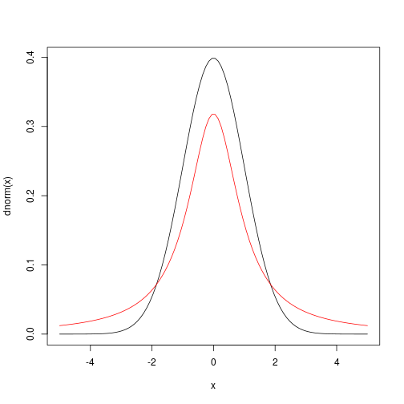

```r
x <- seq(-5, 5, length = 100)
plot(x, dnorm(x), type = 'l')
lines(x, dt(x, df = 1), col = 'red')
```

**POLL 4F**: Suppose you want know the probability of getting 4 or fewer heads when flipping a coin 10 times. Which of the following will work?

1) dbinom(4, size = 10, prob = 0.5) 2) pbinom(4, size = 10, prob = 0.5) 3) qbinom(4, size = 10, prob = 0.5) 4) pbinom(5, size = 10, prob = 0.5) 5) sum(dbinom(0:4, size = 10, prob = 0.5) 6) rbinom(1, size = 10, prob = 0.5)

```r
rmultinom(1, 100, prob = c(.1, .1, .2, .3, .25, .05))
```

```
##      [,1]
## [1,]    3
## [2,]   15
## [3,]   27
## [4,]   25
## [5,]   26
## [6,]    4
```

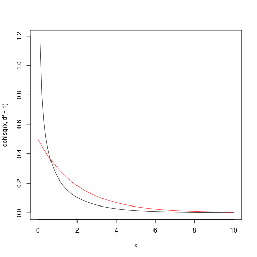

```r
x <- seq(0, 10, length = 100)
plot(x, dchisq(x, df = 1), type = 'l')
lines(x, dchisq(x, df = 2), col = 'red')
```

# Other types of simulation and sampling

We can draw a sample with or without replacement.

```r
sample(1:nrow(gap), 20, replace = FALSE)
```

```
##  [1]  560 1600 1367 1295 1207 1646  852  529 1453  990 1186  341  331 1610
## [15]  628 1702  241   17 1043  610
```

Here's an example of some code that would be part of coding up a bootstrap. As I mentioned previously, this would be a weird dataset to do formal statistical inference on given it includes most of the countries in the world, though one could think about fitting models for the variation over time, treating short-term fluctuations as random.

```r
# actual mean
mean(gap$lifeExp, na.rm = TRUE)
```

```
## [1] 59.47444
```

```r
# here's a bootstrap sample:
smp <- sample(seq_len(nrow(gap)), replace = TRUE)
mean(gap$lifeExp[smp], na.rm = TRUE)
```

```
## [1] 59.17633
```

It's a good idea to use `seq_along()` and `seq_len()` and not syntax like `1:length(gap)` in `sample()` because the outcome of `length()` might in some cases be unexpected (e.g., if you're taking subsets of a dataset). Similar reasoning holds when setting up for loops: e.g.,

```r
for(i in seq_len(nrow(gap))) {
# blah
}
```

# The Random Seed

A few key facts about generating random numbers

- Random number generation is based on generating uniformly between 0 and 1 and then transforming to the kind of random number of interest: normal, categorical, etc.
- Random numbers on a computer are *pseudo-random*; they are generated deterministically from a very, very, very long sequence that repeats
- The *seed* determines where you are in that sequence

To replicate any work involving random numbers, make sure to set the seed first.

```r
set.seed(1)
vals <- sample(1:nrow(gap), 10)
vals
```

```
##  [1] 1017  679  129  930 1533  471  299  270 1211 1331
```

```r
vals <- sample(1:nrow(gap), 10)
vals
```

```
##  [1]  597 1301 1518  330 1615   37 1129  729  878  485
```

```r
set.seed(1)
vals <- sample(1:nrow(gap), 10)
vals
```

```
##  [1] 1017  679  129  930 1533  471  299  270 1211 1331
```

# Strings

R has lots of functionality for character strings. Usually these are stored as vectors of strings, each with arbitrary length.

```r
chars <- c('hi', 'hallo', "mother's", 'father\'s', "He said, \"hi\"" )
length(chars)
```

```
## [1] 5
```

```r
nchar(chars)
```

```
## [1]  2  5  8  8 13
```

```r
paste("Barack", "Obama", sep = " ")  # paste together a set of strings
```

```
## [1] "Barack Obama"
```

```r
paste(chars, collapse = ' ')  # paste together things from a vector
```

```
## [1] "hi hallo mother's father's He said, \"hi\""
```

```r
strsplit("This is the R bootcamp", split = " ")
```

```
## [[1]]
## [1] "This"     "is"       "the"      "R"        "bootcamp"
```

```r
countries <- as.character(gap2007$country)
substring(countries, 1, 3)
```

```
##   [1] "Afg" "Alb" "Alg" "Ang" "Arg" "Aus" "Aus" "Bah" "Ban" "Bel" "Ben"
##  [12] "Bol" "Bos" "Bot" "Bra" "Bul" "Bur" "Bur" "Cam" "Cam" "Can" "Cen"
##  [23] "Cha" "Chi" "Chi" "Col" "Com" "Con" "Con" "Cos" "Cot" "Cro" "Cub"
##  [34] "Cze" "Den" "Dji" "Dom" "Ecu" "Egy" "El " "Equ" "Eri" "Eth" "Fin"
##  [45] "Fra" "Gab" "Gam" "Ger" "Gha" "Gre" "Gua" "Gui" "Gui" "Hai" "Hon"
##  [56] "Hon" "Hun" "Ice" "Ind" "Ind" "Ira" "Ira" "Ire" "Isr" "Ita" "Jam"
##  [67] "Jap" "Jor" "Ken" "Kor" "Kor" "Kuw" "Leb" "Les" "Lib" "Lib" "Mad"
##  [78] "Mal" "Mal" "Mal" "Mau" "Mau" "Mex" "Mon" "Mon" "Mor" "Moz" "Mya"
##  [89] "Nam" "Nep" "Net" "New" "Nic" "Nig" "Nig" "Nor" "Oma" "Pak" "Pan"
## [100] "Par" "Per" "Phi" "Pol" "Por" "Pue" "Reu" "Rom" "Rwa" "Sao" "Sau"
## [111] "Sen" "Ser" "Sie" "Sin" "Slo" "Slo" "Som" "Sou" "Spa" "Sri" "Sud"
## [122] "Swa" "Swe" "Swi" "Syr" "Tai" "Tan" "Tha" "Tog" "Tri" "Tun" "Tur"
## [133] "Uga" "Uni" "Uni" "Uru" "Ven" "Vie" "Wes" "Yem" "Zam" "Zim"
```

```r
tmp <- countries
substring(tmp, 5, 10) <- "______"
tmp[1:20]
```

```
##  [1] "Afgh______n"            "Alba___"
##  [3] "Alge___"                "Ango__"
##  [5] "Arge_____"              "Aust_____"
##  [7] "Aust___"                "Bahr___"
##  [9] "Bang______"             "Belg___"
## [11] "Beni_"                  "Boli___"
## [13] "Bosn______ Herzegovina" "Bots____"
## [15] "Braz__"                 "Bulg____"
## [17] "Burk______so"           "Buru___"
## [19] "Camb____"               "Came____"
```

We can search for patterns in character vectors and replace patterns (both vectorized!)

```r
indexes <- grep("Korea", countries)
indexes
```

```
## [1] 70 71
```

```r
countries[indexes]
```

```
## [1] "Korea Dem. Rep." "Korea Rep."
```

```r
countries2 <- gsub("Korea Dem. Rep.", "North Korea", countries)
countries2[indexes]
```

```
## [1] "North Korea" "Korea Rep."
```

# Regular expressions (regex or regexp)

Some of you may be familiar with using *regular expressions*, which is functionality for doing sophisticated pattern matching and replacement with strings. *Python* and *Perl* are both used extensively for such text manipulation.

R has a full set of regular expression capabilities available through the *grep()*, *gregexpr()*, and *gsub()* functions (among others - many R functions will work with regular expressions). A particularly nice way to make use of this functionality is to use the *stringr* package, which is more user-friendly than directly using the core R functions.

You can basically do any regular expression/string manipulations in R, though the syntax may be a bit clunky at times.

# Dates

- R has built-in ways to handle dates (don't reinvent the wheel!)

```r
date1 <- as.Date("03-01-2011", format = "%m-%d-%Y")
date2 <- as.Date("03/02/11", format = "%m/%d/%y")
date3 <- as.Date("07-May-11", format = "%d-%b-%y")

date1; date2
```

```
## [1] "2011-03-01"
```

```
## [1] "2011-03-02"
```

```r
class(date1)
```

```
## [1] "Date"
```

```r
dates <- c(date1, date2, date3)
weekdays(dates)
```

```
## [1] "Tuesday"   "Wednesday" "Saturday"
```

```r
dates + 30
```

```
## [1] "2011-03-31" "2011-04-01" "2011-06-06"
```

```r
date3 - date2
```

```
## Time difference of 66 days
```

```r
unclass(dates)
```

```
## [1] 15034 15035 15101
```

- The origin date in R is January 1, 1970

# Time too!

```r
library(chron)
d1 <- chron("12/25/2004", "10:37:59")
# default format of m/d/Y and h:m:s
d2 <- chron("12/26/2004", "11:37:59")

class(d1)
```

```
## [1] "chron" "dates" "times"
```

```r
d1
```

```
## [1] (12/25/04 10:37:59)
```

```r
d1 + 33
```

```
## [1] (01/27/05 10:37:59)
```

```r
d2 - d1
```

```
## Time in days:
## [1] 1.041667
```

```r
d1 + d2
```

```
## Error in Ops.dates(d1, d2): chron objects may not be added together
```

There's lots more packages/functionality for dates/times: see *lubridate* and `?DateTimeClasses`

# Breakout

### Basics

1) Create a vector that concatenates the country and year to create a 'country-year' variable in a vectorized way using the string processing functions.

2) Use `table()` to figure out the number of countries available for each continent.

3) Generate 100 random Poisson values with a population mean of 5. How close is the mean of those 100 values to the value of 5?

4) What is the 95th percentile of a chi-square distribution with 1 degree of freedom?

5) What's the probability of getting a value greater than 5 if you draw from a standard normal distribution? What about a t distribution with 1 degree of freedom?

### Using the ideas

6) Explain the steps of what this code is doing: `tmp <- gap[ , -which(names(gap) == "continent")]`.

7) Compute the number of NAs in each column of the gapminder dataset using `sapply()` and making use of the `is.na()` function. It's possible to do this without writing a function (which is a topic we'll cover in Module 5).

8) Discretize gdpPercap into some bins and create a gdpPercap_binned variable. Count the number of values in each bin.

9) Create a boxplot of life expectancy by binned gdpPercap.

10) Sort the dataset and find the shortest life expectancy value. Now consider the use of `which.min()` and why using that should be much quicker with large datasets.

11) Create a dataframe that has the total population across all the countries for each year.

13) Fit two linear regression models from the gapminder data, where the outcome is `lifeExp` and the explanatory variables are `log(pop)`, `log(gdpPercap)`, and `year`. In one model, treat `year` as a numeric variable. In the other, factorize the `year` variable. How do you interpret each model?

14) Suppose we have two categorical variables and we conduct a hypothesis test of independence. The chi-square statistic is:

\[ \chi^2 = \sum_{i=1}^{n}\sum_{j=1}^{m} \frac{(y_{ij} - e_{ij})^2}{e_{ij}}, \]

where \(e_{ij} = \frac{y_{i\cdot} y_{\cdot j}}{y_{\cdot \cdot}}\), with \(y_{i\cdot}\) the sum of the values in the i'th row, \(y_{\cdot j}\) the sum of values in the j'th column, and \(y_{\cdot\cdot}\) the sum of all the values. Suppose I give you a matrix in R with the \(y_{ij}\) values.

You can generate a test matrix as:

```r
y <- matrix(sample(1:10, 12, replace = TRUE),
nrow = 3, ncol = 4)
```

Compute the statistic without *any* loops as follows:

a. First, assume you have the *e* matrix. How do you compute the statistic without loops as a function of `y` and `e`? b. How can you construct the *e* matrix? Hint: the numerator of *e* is just an *outer product* for which the `outer()` function can be used.

### Advanced

15) For each combination of year and continent, find the 95th percentile of life expectancy.

16) Fit a logistic regression model where the outcome is whether `lifeExp` is greater than or less than 60 years, exploring the use of different predictors.

17) Suppose you wanted to do 10-fold cross-validation for some sort of regression model fit to the *gap* dataset. Write some R code that produces a field in the dataset that indicates which fold each observation is in. Ensure each of the folds has an equal (or as nearly equal as possible if the number of observations is not divisible by 10) number of observations. Hint: consider the *times* argument to the `rep()` function. (If you're not familiar with 10-fold cross-validation, it requires one to divide the dataset into 10 subsets of approximately equal size.)